# Women’s Football Results: Analysis and Visualization

# Resultados de Competições Internacionais de Futebol Feminino por Marina Fajardo

Link: https://www.kaggle.com/martj42/womens-international-football-results

Dados técnicos: conjunto de dados de domínio público do Kaggle, nota 10 em “usability”, disponibilizado via arquivo csv de 52KB. Possui 6.284 views, 978 downloads e 18 notebooks.

Atualmente conta com 4.163 resultados de partidas de futebol feminino de principais torneios mundiais bem como amistosos ocorridos entre 01/11/1969 e 11/03/2020. Os dados foram raspados da Wikipedia, fifa.com, rsssf.com e alguns sites de associações individuais de futebol.

Tags: sports, football, history, internacional relations

## Introdução

Após download do dataset e tratamento de dados, foram feitas análises que abordam os placares mais comuns nas competições, os times com maiores saldos de gols, além de quais foram mais participativos e como a composição do campeonato mudou ao longo dos anos.

## Baixando Pacotes necessários

```r
library(data.table)
library(ggplot2)
library(dplyr)
library(grid)
library(stringr)
library(forcats)
library(kableExtra)
library(plotrix)
library(wordcloud)
library(RColorBrewer)
library(Amelia)
library(viridis)
library(paletteer)
```

## Baixando o dataset

```r
df <- fread('original-dataset-20201117.csv')
head(df) %>% kbl(caption = 'Amostra do Dataset') %>% kable_paper("striped", full_width = F) %>% row_spec(0, bold = T) %>% footnote('Womens International Football Results (1969 - 2020)')
```

Amostra do Dataset

| date | home_team | away_team | home_score | away_score | tournament | city | country | neutral |
| --- | --- | --- | --- | --- | --- | --- | --- | --- |
| 1969-11-01 | Italy | France | 1 | 0 | Euro | Novara | Italy | FALSE |
| 1969-11-01 | Denmark | England | 4 | 3 | Euro | Aosta | Italy | TRUE |
| 1969-11-02 | England | France | 2 | 0 | Euro | Turin | Italy | TRUE |
| 1969-11-02 | Italy | Denmark | 3 | 1 | Euro | Turin | Italy | FALSE |
| 1975-08-25 | Thailand | Australia | 3 | 2 | AFC Championship | Hong Kong | Hong Kong | TRUE |
| 1975-08-25 | Hong Kong | New Zealand | 0 | 2 | AFC Championship | Hong Kong | Hong Kong | FALSE |

Note:  
Womens International Football Results (1969 - 2020)

## Dicionário de Dados

```r
variaveis <- data.frame(variavel = c('date', 'home_team', 'away_team', 'home_score', 'away_score', 'tournament', 'city', 'country','neutral'),
                        descricao = c('data da partida', 'nome do time da casa', 'nome do time convidado', 'placar do time da casa (tempo normal de jogo + prorrogações. Pênaltis não considerados)', 'placar do time convidado (tempo normal de jogo + prorrogações. Pênaltis não considerados)', 'nome do torneio', 'nome da cidade onde a partida foi realizada', 'nome do país onde a partida foi realizada', 'VERDADEIRO/FALSO - indica se a partida foi realizada em um local neutro para as duas equipes'),
                        tipo_de_dados = c('IDate', 'Character','Character','Integer','Integer',
                                          'Character', 'Character', 'Character', 'Logical'),
                        valores_permitidos = c('datas', 'texto', 'texto', 'números inteiros', 'números inteiros',
                                               'texto', 'texto', 'texto', 'valores lógicos'))

variaveis %>%
  rename('Variável' = variavel,
         'Descrição' = descricao,
         'Tipo de Dados' = tipo_de_dados,
         'Valores Permitidos' = valores_permitidos) %>%
  kbl() %>%
  kable_paper("striped", full_width = F) %>%
  column_spec(1, italic = T) %>%
  row_spec(0, bold = T)
```

| Variável | Descrição | Tipo de Dados | Valores Permitidos |
| --- | --- | --- | --- |
| date | data da partida | IDate | datas |
| home_team | nome do time da casa | Character | texto |
| away_team | nome do time convidado | Character | texto |
| home_score | placar do time da casa (tempo normal de jogo + prorrogações. Pênaltis não considerados) | Integer | números inteiros |
| away_score | placar do time convidado (tempo normal de jogo + prorrogações. Pênaltis não considerados) | Integer | números inteiros |
| tournament | nome do torneio | Character | texto |
| city | nome da cidade onde a partida foi realizada | Character | texto |
| country | nome do país onde a partida foi realizada | Character | texto |
| neutral | VERDADEIRO/FALSO - indica se a partida foi realizada em um local neutro para as duas equipes | Logical | valores lógicos |

## Preparação dos Dados

Feita cópia do dataset para transformações necessárias e preservação do dataset original.

```r
novo_df <- df
```

Verificando e acertando nomes escritos de formas diferentes:

```r
novo_df$home_team <- novo_df$home_team %>%
    str_replace_all('CuraÃ§ao', 'Curaçao') %>%
    str_replace_all('DR Congo', 'Congo') %>%
    str_replace_all('India N', 'India') %>%
    str_replace_all('India S', 'India') %>%
    str_replace_all('RÃ©union', 'Reunion') %>%
    str_replace_all('SÃ£o TomÃ© and PrÃncipe', 'San-Tome and Principe')


novo_df$away_team <- novo_df$away_team %>%
    str_replace_all('CuraÃ§ao', 'Curaçao') %>%
    str_replace_all('DR Congo', 'Congo') %>%
    str_replace_all('India N', 'India') %>%
    str_replace_all('RÃ©union', 'Reunion') %>%
    str_replace_all('SÃ£o TomÃ© and PrÃncipe', 'San-Tome and Principe')


novo_df$country <- novo_df$country %>%
    str_replace_all('DR Congo', 'Congo') %>%
    str_replace_all('RÃ©union', 'Reunion') %>%
    str_replace_all('SÃ£o TomÃ© and PrÃncipe', 'San-Tome and Principe')


novo_df$tournament <- novo_df$tournament %>%
    str_replace_all('Copa AmÃ©rica', 'Copa América') %>%
    str_replace_all('Euro', 'UEFA Euro')
```

Alterações realizadas:

```r
changes <- data.frame(Anterior = c('CuraÃ§ao', 'DR Congo e Congo', 'India, India N e India S', 'RÃ©union','SÃ£o TomÃ© and PrÃncipe', 'Copa AmÃ©rica', 'Euro'),
           Novo = c('Curaçao', 'Congo', 'India', 'Reunion', 'San-Tome and Principe', 'Copa América', 'UEFA Euro'))
changes %>% kbl() %>% kable_paper('striped',full_width = F, position = "center") %>% column_spec(c(1,2), width = '5cm') %>% row_spec(0, bold = T)
```

| Anterior | Novo |
| --- | --- |
| Curaçao | Curaçao |
| DR Congo e Congo | Congo |
| India, India N e India S | India |
| Réunion | Reunion |
| São Tomé and Príncipe | San-Tome and Principe |
| Copa América | Copa América |
| Euro | UEFA Euro |

Há, ainda, alguns países que não sofreram alterações pois eram antigas uniões entre terras, que eram verdadeiras de acordo com as datas dos jogos. São eles: Czechoslovakia (recentes Czech Republic e Slovakia), Netherlands Antilles (conjunto de terras que originou Netherlands) e Serbia and Montenegro (recentes Serbia e Montenegro)

A coluna que contém data está classificada como “IDate” e “Date”. Contudo, caso seja necessário no futuro realizar algum outro tipo de análise utilizando hora, seria conveniente transformar a coluna “Date” para o padrão POSIXct.

```r
novo_df$date <- as.POSIXct(novo_df$date)
```

As colunas que contém os times, países, torneios e cidades (home_team, away_team, country, tournament e city) devem ser convertidas para fatores.

```r
novo_df$home_team <- as.factor(novo_df$home_team)
novo_df$away_team <- as.factor(novo_df$away_team)
novo_df$country <- as.factor(novo_df$country)
novo_df$tournament <- as.factor(novo_df$tournament)
novo_df$city <- as.factor(novo_df$city)
```

Nenhum valor NA foi encontrado no dataset

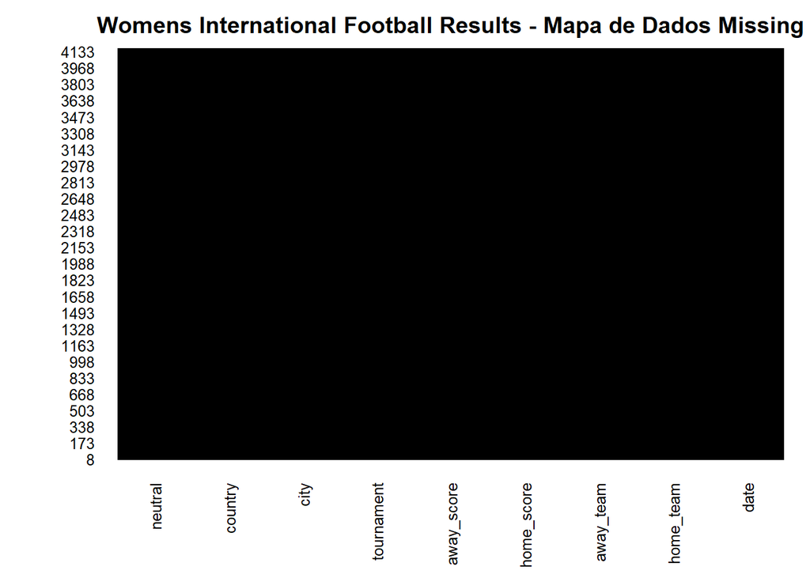

```r
missmap(novo_df,
        main = "Womens International Football Results - Mapa de Dados Missing",
        col = c("yellow", "black"),
        legend = FALSE)
```

## Resumo dos dados

```r
summary(novo_df) %>% kbl() %>% kable_paper('striped',full_width = F, font_size = 13)
```

|  | date | home_team | away_team | home_score | away_score | tournament | city | country | neutral |
| --- | --- | --- | --- | --- | --- | --- | --- | --- | --- |
|  | Min. :1969-11-01 00:00:00 | China PR : 184 | Denmark: 144 | Min. : 0.000 | Min. : 0.00 | UEFA UEFA Euro qualification :1241 | Lagos : 85 | Portugal : 580 | Mode :logical |
|  | 1st Qu.:1999-03-20 00:00:00 | Norway : 167 | Norway : 139 | 1st Qu.: 0.000 | 1st Qu.: 0.00 | Algarve Cup : 545 | Albufeira: 67 | China PR : 225 | FALSE:2324 |
|  | Median :2007-04-14 00:00:00 | Sweden : 160 | Sweden : 137 | Median : 1.000 | Median : 1.00 | FIFA World Cup : 284 | Parchal : 60 | United States: 186 | TRUE :1839 |
|  | Mean :2005-11-13 20:28:39 | Germany : 157 | Germany: 114 | Mean : 2.296 | Mean : 1.45 | AFC Championship : 268 | Hong Kong: 57 | Sweden : 102 | NA |
|  | 3rd Qu.:2014-10-16 00:00:00 | United States: 155 | Finland: 110 | 3rd Qu.: 3.000 | 3rd Qu.: 2.00 | African Championship qualification: 226 | Guangzhou: 55 | Germany : 100 | NA |
|  | Max. :2020-03-11 00:00:00 | Portugal : 139 | England: 92 | Max. :24.000 | Max. :24.00 | African Championship : 173 | Faro : 53 | France : 99 | NA |
|  | NA | (Other) :3201 | (Other):3427 | NA | NA | (Other) :1426 | (Other) :3786 | (Other) :2871 | NA |

## Análise Exploratória

Criação de um dataframe completo para análises. Colunas inseridas:

```r
novas_colunas <- data.frame(Coluna = c('Placar', 'Vencedor', 'Ano', 'Década'),
                            Descricao = c('Juntação de home_score e away_score, indicando o placar da partida', 'Informa o vencedor da partida', 'Informa o ano de realização da partida, últil para plotagens futuras', 'As décadas foram divididas em 4 com 10 anos cada e 1, a primeira, contendo 11 anos. Década 1 = 1969 - 1980, Década 2 = 1981 - 1990, Década 3 = 1991 - 2000, Década 4 = 2001 - 2010 e Década 5 = 2011 - 2020'))

novas_colunas %>%
  rename('Descrição' = Descricao) %>%
  kbl() %>%
  kable_paper('striped',full_width = F, position = 'center') %>%
  column_spec(1, italic = T, width = '5cm') %>%
  column_spec(2, width = "40cm") %>%
  row_spec(0, bold = T)
```

[output not shown]

Novo data frame de trabalho:

```r
completo <- novo_df %>%
  mutate(placar = paste(home_score, 'x', away_score)) %>%
  mutate(vencedor = ifelse(novo_df$home_score > novo_df$away_score, as.character(home_team), ifelse(novo_df$home_score == novo_df$away_score,  'empate', as.character(away_team)))) %>%
  mutate(ano = year(date)) %>%
  mutate(decada = ifelse(date <= '1980-12-31', 'Década 1', ifelse(date <= '1990-12-31', 'Década 2', ifelse(date <= '2000-12-31', 'Década 3', ifelse(date <= '2010-12-31', 'Década 4', 'Década 5')))))

completo$placar <- as.factor(completo$placar)
completo$vencedor <- as.factor(completo$vencedor)
completo$ano <- as.factor(completo$ano)
completo$decada <- as.factor(completo$decada)

head(completo) %>% kbl() %>% kable_paper('striped',full_width = F, font_size = 13)
```

| date | home_team | away_team | home_score | away_score | tournament | city | country | neutral | placar | vencedor | ano | decada |
| --- | --- | --- | --- | --- | --- | --- | --- | --- | --- | --- | --- | --- |
| 1969-11-01 | Italy | France | 1 | 0 | UEFA Euro | Novara | Italy | FALSE | 1 x 0 | Italy | 1969 | Década 1 |
| 1969-11-01 | Denmark | England | 4 | 3 | UEFA Euro | Aosta | Italy | TRUE | 4 x 3 | Denmark | 1969 | Década 1 |
| 1969-11-02 | England | France | 2 | 0 | UEFA Euro | Turin | Italy | TRUE | 2 x 0 | England | 1969 | Década 1 |
| 1969-11-02 | Italy | Denmark | 3 | 1 | UEFA Euro | Turin | Italy | FALSE | 3 x 1 | Italy | 1969 | Década 1 |
| 1975-08-25 | Thailand | Australia | 3 | 2 | AFC Championship | Hong Kong | Hong Kong | TRUE | 3 x 2 | Thailand | 1975 | Década 1 |
| 1975-08-25 | Hong Kong | New Zealand | 0 | 2 | AFC Championship | Hong Kong | Hong Kong | FALSE | 0 x 2 | New Zealand | 1975 | Década 1 |

### Analisando Placares

Através da medida estatística moda, calculamos o placar que mais ocorreu no período estudado:

```r
moda <- function(x){
    z <- table(as.vector(x))
    names(z)[z == max(z)]
}

paste('O placar que mais ocorreu foi o de ', moda(completo$placar),'.')
```

```
## [1] "O placar que mais ocorreu foi o de  1 x 0 ."
```

Abaixo um mapa de calor que demonstra os placares que mais ocorreram ao longo do campeonato. Vemos claramente que o placar de 1 x 0 foi a combinação mais recorrente.

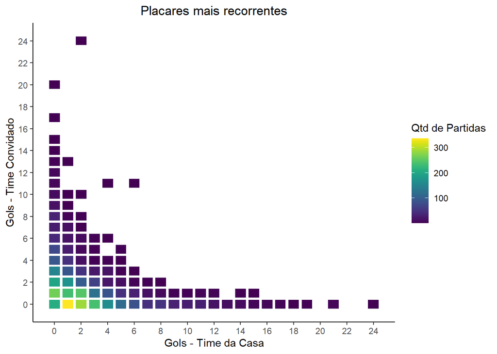

```r
completo %>%
  count(home_score, away_score) %>%
  ggplot(aes(x = home_score, y = away_score)) + geom_tile(aes(fill = n), width=0.8, height=0.8) +
  scale_x_continuous(breaks = seq(0, 24, 2)) +
  scale_y_continuous(breaks = seq(0, 24, 2)) +
  labs(title = 'Placares mais recorrentes',
       x = 'Gols - Time da Casa',
       y = 'Gols - Time Convidado',
       fill = 'Qtd de Partidas') +
  scale_fill_viridis() +
  theme_classic() +
  theme(plot.title = element_text(hjust = 0.5)) +
  theme(panel.background = element_blank())
```

### Gols marcados, sofridos e saldo de gols

Ranking times que mais fizeram gols

```r
gols_casa <- completo %>%
    group_by(home_team) %>%
    summarise(gols = sum(home_score))

gols_fora <- completo %>%
  group_by(away_team) %>%
  summarise(gols = sum(away_score))

gols <- inner_join(gols_casa, gols_fora, by = c('home_team' = 'away_team'))

gols %>%
  mutate(total = gols.x + gols.y) %>%
  select(home_team, total) %>%
  arrange(desc(total)) %>%
  rename('Equipe' = home_team,
         'Gols feitos' = total) %>%
  head(10) %>%
  kbl() %>% kable_paper('striped',full_width = F, position = "left") %>%
  row_spec(c(1:3), bold = T, color = "white", background = "#440154FF")
```

| Equipe | Gols feitos |
| --- | --- |
| Germany | 769 |
| Norway | 689 |
| United States | 651 |
| China PR | 637 |
| Sweden | 611 |
| Denmark | 495 |
| Japan | 460 |
| Brazil | 417 |
| England | 384 |
| New Zealand | 368 |

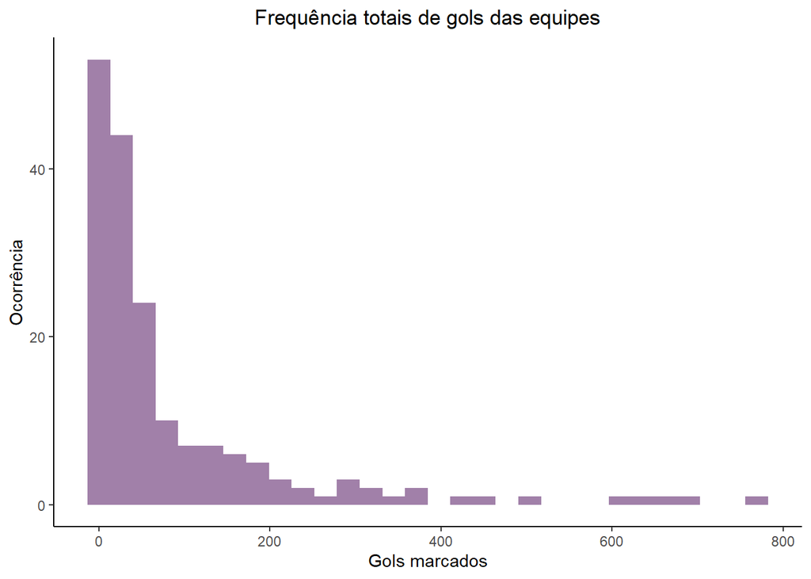

```r
gols %>%
  rename(team = 'home_team') %>%
  mutate(total = gols.x + gols.y) %>%
  select(team, total) %>%
  arrange(desc(total)) %>%
  ggplot() + geom_histogram(aes(total), fill = '#440154FF', alpha = .5) +
  guides(fill=F) +
  labs(title = 'Frequência totais de gols das equipes',
       x = 'Gols marcados',
       y = 'Ocorrência') +
  theme_classic() + theme(plot.title = element_text(hjust = 0.5))
```

Ranking times com melhores saldos de gols (gols feitos - gols sofridos)

```r
saldo_casa <- completo %>%
    mutate(saldo = home_score - away_score) %>%
    group_by(home_team) %>%
    summarise(sum = sum(saldo)) %>%
    arrange(desc(sum))

saldo_fora <- completo %>%
  mutate(saldo = home_score - away_score) %>%
  group_by(away_team) %>%
  summarise(sum = sum(saldo)) %>%
  arrange(desc(sum))

saldos <- inner_join(saldo_casa, saldo_fora, by = c('home_team' = 'away_team'))

saldos %>%
  mutate(total = sum.x + sum.y) %>%
  select(home_team, total) %>%
  arrange(desc(total)) %>%
  rename('Equipe' = home_team,
         'Saldo de Gols' = total) %>%
  head(10) %>%
  kbl() %>% kable_paper('striped',full_width = F, position = "left") %>%
  row_spec(c(1:3), bold = T, color = "white", background = "#440154FF")
```

| Equipe | Saldo de Gols |
| --- | --- |
| China PR | 296 |
| United States | 292 |
| Japan | 238 |
| Norway | 210 |
| Trinidad and Tobago | 193 |
| Canada | 169 |
| North Korea | 158 |
| Finland | 158 |
| Brazil | 153 |
| Germany | 143 |

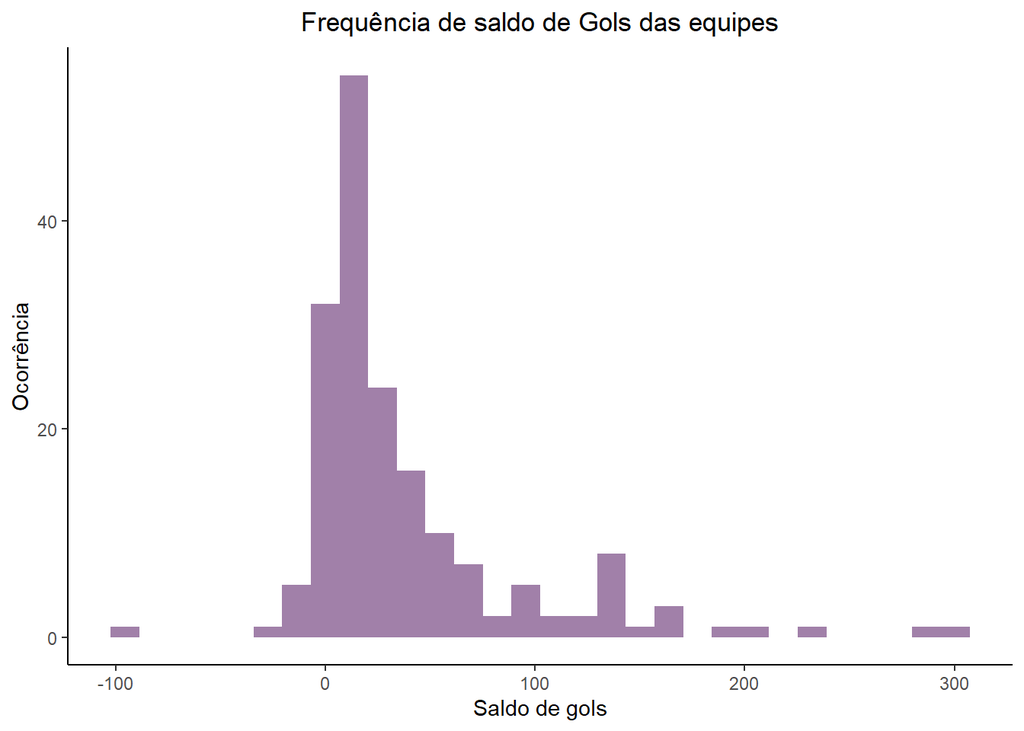

```r
saldos %>%
  rename(team = 'home_team') %>%
  mutate(total = sum.x + sum.y) %>%
  select(team, total) %>%
  arrange(desc(total)) %>%
  ggplot() + geom_histogram(aes(total), fill = '#440154FF', alpha = .5) +
  labs(title = 'Frequência de saldo de Gols das equipes',
       x = 'Saldo de gols',
       y = 'Ocorrência') +
  theme_classic() + theme(plot.title = element_text(hjust = 0.5))
```

Apesar da Alemanha ter potencial ofensivo expressivo (tendo marcado 769 gols), ela ocupa apenas a décima posição se analisado o saldo de gols (com 143 gols). China, Estados Unidos e Japão aparentam ter potencial ofensivo e defensivo mais equilibrado. Existem muitas equipes com saldo de gols próximos de zero e algumas ainda com saldos negativos.

Ainda podemos observar pela análise dos histogramas, a maior frequencia de equipes que não marcam muitos gols ou não possuem saldos de gols tão elevados. As poucas super goleadores ou com alto saldo de gols podem ser consideradas outliers.

Ainda podemos verificar a diferença de gols entre as partidas e se houve muita mudança ao longo dos anos: Entende-se por diferença de gols a subtração dos gols feitos pelo time da casa dos gols feitos pelo time convidado.

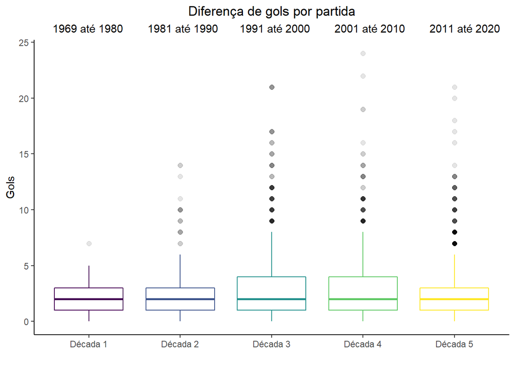

```r
cores_5 <- as.vector(paletteer_c("viridis::viridis", n = 5, direction = 1))

completo %>%
  mutate(gd = ifelse(home_score - away_score >= 0, home_score - away_score,  away_score - home_score)) %>%
  select(decada, gd) %>%
  arrange(desc(gd)) %>%
  ggplot(aes(decada, gd, color = decada)) + geom_boxplot(color = cores_5, outlier.colour = 'black', outlier.alpha = .10, outlier.size = 2) +
  labs(title = 'Diferença de gols por partida',
       subtitle = '      1969 até 1980        1981 até 1990       1991 até 2000        2001 até 2010        2011 até 2020',
       x = '',
       y = 'Gols')  +
  theme_classic() +
  theme(legend.position="none") + theme(plot.title = element_text(hjust = 0.5))
```

Nota-se que não há muitas alterações relevantes se compararmos as médias de diferenças de gols entre as décadas. No entanto, podemos perceber que a partir de 1991 houve importante aumento de maiores diferenças, o que pode indicar certa disparidade na qualidade de algumas equipes.

### Vitórias e Derrotas

Abaixo os times mais e menos vitoriosos

```r
mais_vitoriosos <- completo %>%
    group_by(vencedor) %>%
    summarise(vitorias = n()) %>%
    filter(vencedor != 'empate') %>%
    arrange(desc(vitorias)) %>%
    rename('Equipe' = vencedor,
           'Quantidade de Vitórias' = vitorias) %>%
    head(5)

menos_vitoriosos <- completo %>%
    group_by(vencedor) %>%
    summarise(vitorias = n()) %>%
    arrange(desc(vitorias)) %>%
    rename('Equipe' = vencedor,
           'Quantidade de Vitórias' = vitorias) %>%
    tail(5)

lista <- data.frame(Equipe = c(as.character(mais_vitoriosos$Equipe), as.character(menos_vitoriosos$Equipe)),
                    qtd_vitorias = c(mais_vitoriosos$`Quantidade de Vitórias`, menos_vitoriosos$`Quantidade de Vitórias`))
lista <- lista %>%
  rename('Quantidade de Vitórias' = qtd_vitorias)

lista %>%
  kbl() %>% kable_paper('striped',full_width = F, position = 'left') %>%
  row_spec(0, bold = T)
```

| Equipe | Quantidade de Vitórias |
| --- | --- |
| Germany | 190 |
| Norway | 184 |
| United States | 183 |
| Sweden | 165 |
| China PR | 147 |
| Samoa | 1 |
| Serbia and Montenegro | 1 |
| Tahiti | 1 |
| Tajikistan | 1 |
| Uganda | 1 |

Alemanha, Noruega e Estados Unidos são as equipes mais vitoriosas, enquanto Tahiti, Tajiquistão e Uganda compõem um grande grupo que teve apenas uma vitória ao longo de sua participação.

Podemos, também, plotar um balanço de desempenho das equipes mais e menos vitoriosas:

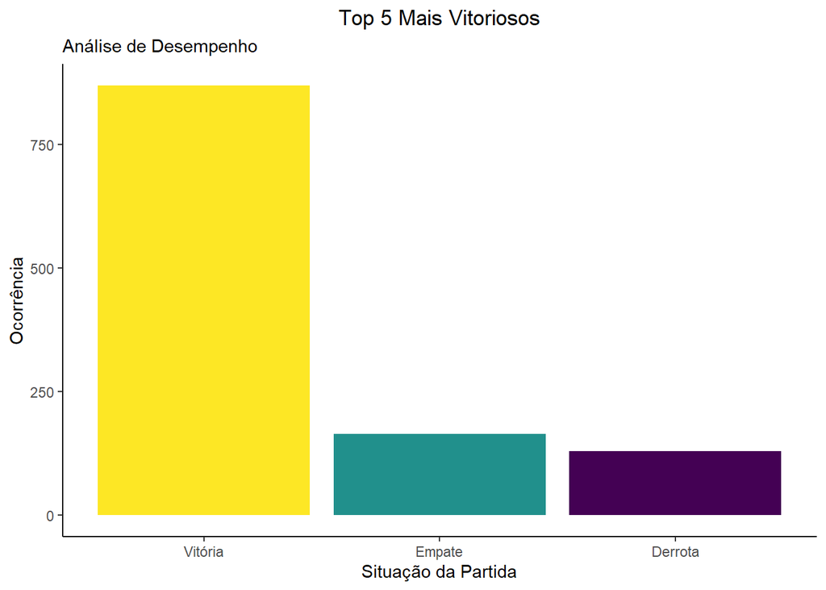

```r
top5_vitorias <- c('Germany', 'Norway', 'United States', 'Sweden', 'China PR')
top5_derrotas <- c('Samoa', 'Serbia and Montenegro', 'Tahiti', 'Tajikistan', 'Uganda')
cores_3 <- as.vector(paletteer_c("viridis::viridis", n = 3, direction = 1))

completo %>%
  filter(home_team %in% top5_vitorias | away_team %in% top5_vitorias) %>%
  mutate(classificador = ifelse(vencedor %in% top5_vitorias, 'Vitória', ifelse(vencedor == 'empate', 'Empate', 'Derrota'))) %>%
  group_by(classificador) %>%
  summarise(qtd = n()) %>%
  ggplot(aes(x = fct_reorder(classificador, qtd, .desc = T), y = qtd, fill = classificador)) + geom_col(fill = cores_3) +
  guides(fill =F) +
  labs(title = 'Top 5 Mais Vitoriosos',
       subtitle = 'Análise de Desempenho',
       x = 'Situação da Partida',
       y = 'Ocorrência') +
  theme_classic() +
  theme(plot.title = element_text(hjust = 0.5))
```

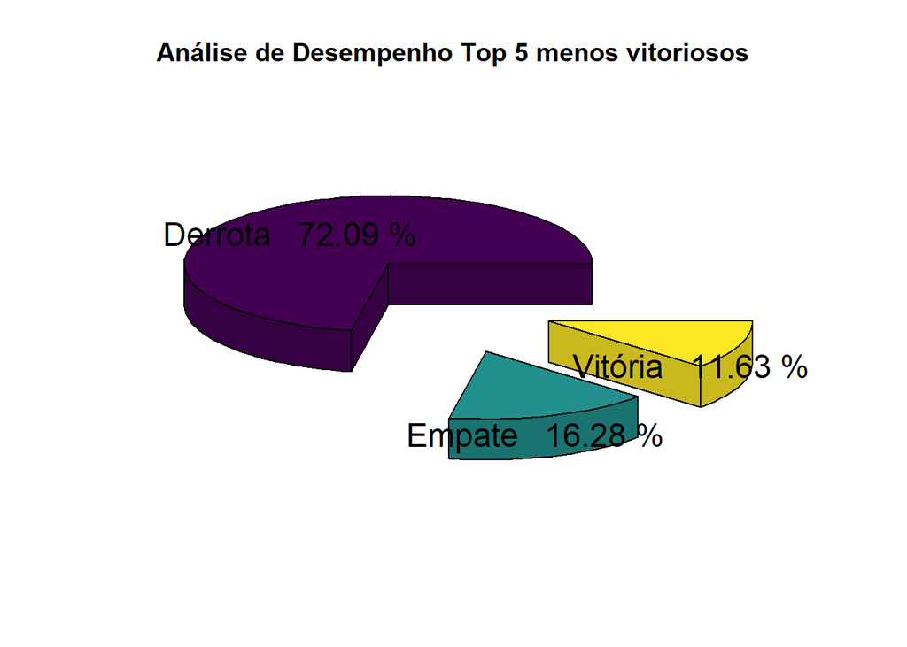

```r
derrotados <- completo %>%
  filter(home_team %in% top5_derrotas | away_team %in% top5_derrotas) %>%
  mutate(classificador = ifelse(vencedor %in% top5_derrotas, 'Vitória', ifelse(vencedor == 'empate', 'Empate', 'Derrota'))) %>%
  group_by(classificador) %>%
  summarise(qtd = n()) %>%
  mutate(Percentual = (qtd / sum(qtd)) * 100)

legenda_percentual <- paste(derrotados$classificador,' ' ,round(derrotados$Percentual,2), '%')

pie3D(derrotados$Percentual, labels = legenda_percentual ,explode = 0.5,
      col = cores_3,
      main = 'Análise de Desempenho Top 5 menos vitoriosos')
```

Enquanto as equipes mais vitoriosas obtiveram, em sua esmagadora maioria, vitórias em suas partidas, as menos vitoriosas apresentaram menos de 12% de jogos bem sucedidos.

Se analisarmos as competições que não ocorreram em lugares neutros, a Noruega lidera o ranking de vitórias, seguida pela Alemanha e Dinamarca. Os Estados Unidos não aparecem entre os dez primeiros lugares. Jogar em casa pode ser um fator relevante para a equipe estadunidense.

```r
completo %>%
    filter(neutral == F) %>%
    select(away_team, vencedor) %>%
    mutate(time_fora = ifelse(as.character(away_team) == as.character(vencedor), as.character(away_team), 'nada')) %>%
    group_by(time_fora) %>%
    filter(time_fora != 'nada') %>%
    summarise(qtd = n()) %>%
    arrange(desc(qtd)) %>%
    rename('Equipe' = time_fora,
           'Vitórias fora de casa' = qtd) %>%
    head(10) %>%
    kbl() %>% kable_paper('striped', full_width = F, position = "left") %>%
    row_spec(1:3, color = 'white', background = '#440154FF', bold = T)
```

| Equipe | Vitórias fora de casa |
| --- | --- |
| Norway | 44 |
| Germany | 42 |
| Denmark | 39 |
| Sweden | 39 |
| England | 35 |
| Italy | 35 |
| Russia | 28 |
| France | 26 |
| Iceland | 22 |
| Netherlands | 21 |

Apesar das poucas vitórias, Portugal foi o local que mais sediou competições:

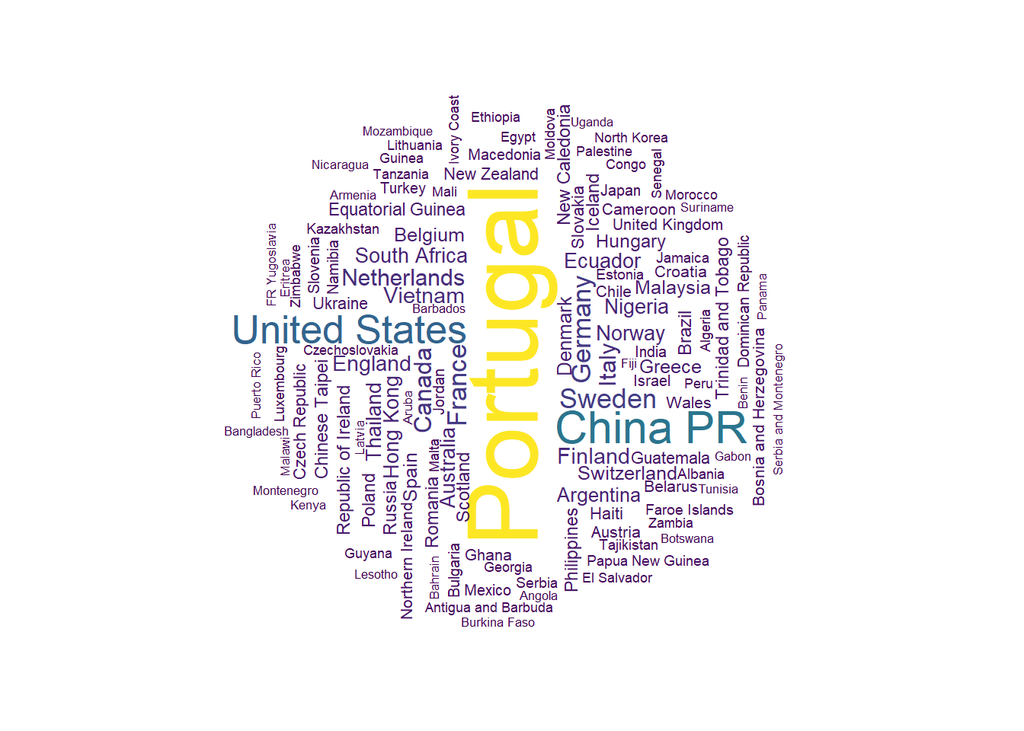

```r
df_country <- as.data.frame(table(completo$country))

cores_mapa_palavras <- paletteer_c("viridis::viridis", n = 143, direction = 1)

wordcloud(words = df_country$Var1, freq = df_country$Freq, random.order = FALSE, rot.per = 0.35 ,colors = cores_mapa_palavras)
```

Ainda podemos conferir qual o time que mais venceu quando a partida ocorreu em local neutro para as duas equipes

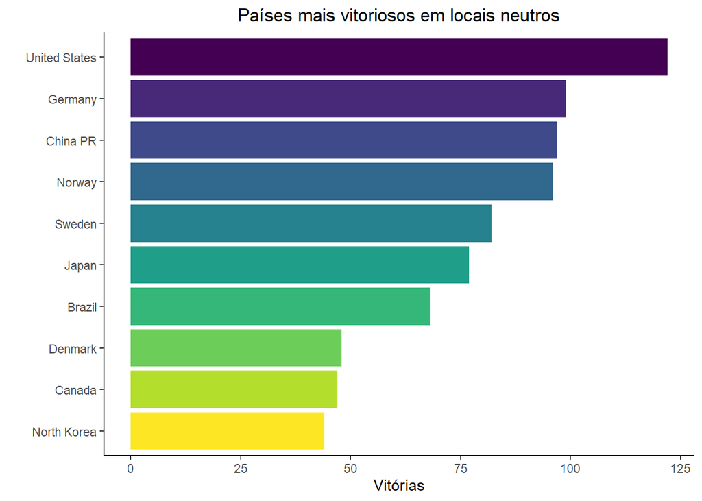

```r
cores_10 <- as.vector(paletteer_c("viridis::viridis", n = 10, direction = 1))

completo %>%
  filter(neutral == T) %>%
  count(vencedor) %>%
  arrange(desc(n)) %>%
  filter(vencedor != 'empate') %>%
  head(10) %>%
  ggplot(aes(x = fct_reorder(vencedor, n, .desc = F), y = n, fill = vencedor)) +
  geom_col(fill = cores_10) + guides(fill = F) +
  labs(title ='Países mais vitoriosos em locais neutros',
       x = '',
       y = 'Vitórias') +
  theme_classic() +
  theme(plot.title = element_text(hjust = 0.5)) +
  coord_flip()
```

Alemanha,China e Noruega voltam a aparecer como importantes equipes. Os Estados Unidos demonstram que possuem uma equipe consistente, tendo além de um ótimo saldo de gols e sustentando-se como uma das equipes mais vitoriosas, capacidade de realizar bons jogos mesmo fora de casa.

### Times e países mais participativos:

Percebemos no gráfico abaixo o aumento significativo da quantidade de partidas realizadas ao longo das décadas

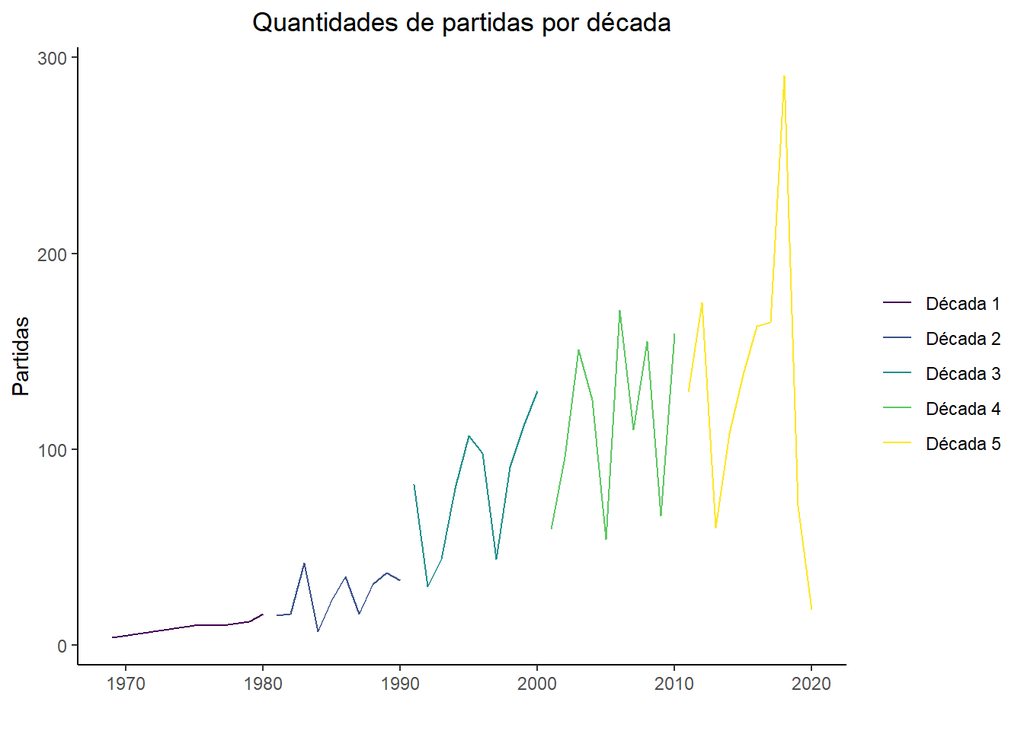

```r
completo %>%
    group_by(decada, ano) %>%
    mutate(ano = as.character(ano)) %>%
    mutate(ano = as.numeric(ano)) %>%
    filter(vencedor != 'empate') %>%
    summarise(qtd = n()) %>%
    ggplot(aes(x = ano, y = qtd)) + geom_line(aes(group = decada, colour = decada)) +
    labs(title = 'Quantidades de partidas por década', x = '', y = 'Partidas') +
    theme_classic() +
    scale_color_manual('', values = cores_5) +
    theme(plot.title = element_text(hjust = 0.5)) +
    scale_x_continuous(breaks = seq(1960, 2020, 10))
```

Quais são os continentes mais participativos e como mudou a composição dos campeonatos de forma geral?

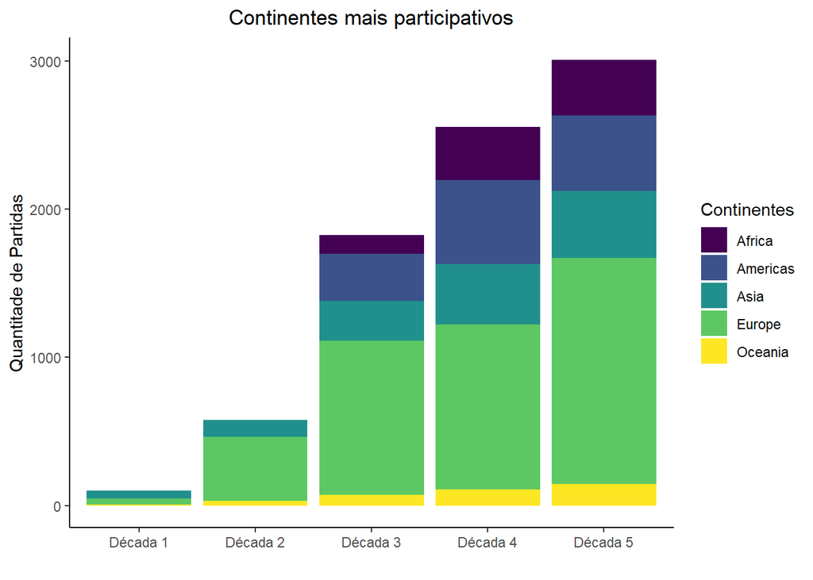

```r
times <- data.frame(time = c(as.character(completo$home_team), as.character(completo$away_team)), decada = c(as.character(completo$decada), as.character(completo$decada)), stringsAsFactors = F)

times_contagem_decada <- times %>%
  group_by(time, decada) %>%
  summarise(qtd = n()) %>%
  arrange(desc(qtd))

continentes <- fread('countryContinent.csv') %>% select(country, continent)


times_contagem_decada_continente <- full_join(times_contagem_decada, continentes, by = c('time' = 'country'))

times_contagem_decada_continente %>%
  filter(!is.na(continent)) %>%
  ggplot(aes(x = decada, y = qtd, fill = continent)) + geom_bar(stat = 'identity') +
  labs(title = 'Continentes mais participativos', x = '', y = 'Quantitade de Partidas') +
  scale_x_discrete(limits = c('Década 1', 'Década 2', 'Década 3', 'Década 4', 'Década 5')) +
  scale_fill_discrete(name = '') +
  scale_fill_manual("Continentes", values = cores_5) +
  theme_classic() +
  theme(plot.title = element_text(hjust = 0.5))
```

No início dos anos 70, basicamente países pertencentes à Europa, Ásia e Oceania disputavam torneios internacionais. A partir de 1991, percebe-se entrada de países do continente africano. Mesmo assim, em 2020, apesar da forte presença da América, a Europa segue sendo o mais relevante continente na composição dos campeonatos mundiais de futebol feminino.

De forma geral, quais foram os países mais participativos?

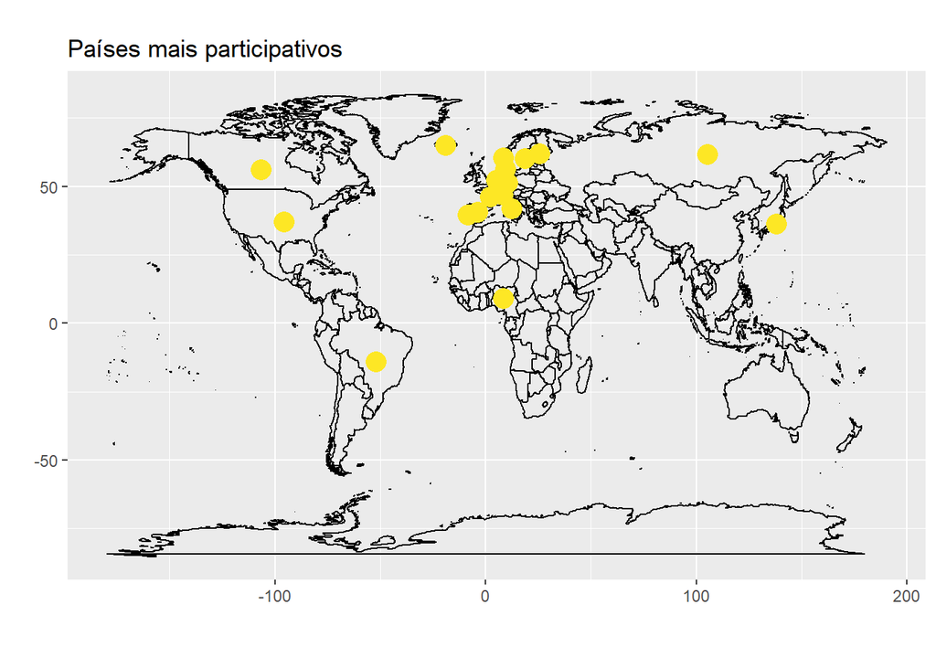

```r
times_contagem <- times %>%
  group_by(time) %>%
  summarise(qtd = n()) %>%
  arrange(desc(qtd))

top_20 <- head(times_contagem,20)

latlong <- fread('long_lat.csv') %>% select(latitude, longitude, country)

top_20_latlong <- latlong %>% filter(country %in% top_20$time)

mapa <- map_data("world")
graf <- ggplot() +
    geom_polygon(data = mapa, aes(x=long, y = lat, group = group), fill = NA, color = "black") +
    coord_fixed(1.3) + labs(title = 'Países mais participativos')

graf +
    geom_point(data = top_20_latlong, aes(x = longitude, y = latitude), color = "#440154FF", size = 5) +
    geom_point(data = top_20_latlong, aes(x = longitude, y = latitude), color = "#FDE725FF", size = 5)  + labs(x = '', y = '')
```

Observa-se claramente a hegemonia dos países europeus nos campeonatos.